# Project

fazal hyder and alisha surani

2023-12-02

# ANALYSIS ON ONLINE RETAIL TRASACTIONAL DATABASE

```r
library(dplyr)
library(ggplot2)
library(lubridate)
library(ggplot2)
library(dplyr)
library(visdat)
library(tidyr)
library(naniar)
library(arules)
library(readxl)
library(cluster)


dataset <- read_excel("Dataset 15-Online Retail.xlsx")

str(dataset)
```

```
## tibble [20,000 × 8] (S3: tbl_df/tbl/data.frame)
##  $ InvoiceNo  : chr [1:20000] "580367" "580367" "580367" "580367" ...
##  $ StockCode  : chr [1:20000] "23328" "23334" "23340" "23343" ...
##  $ Description: chr [1:20000] "SET 6 SCHOOL MILK BOTTLES IN CRATE" "IVORY WICKER HEART SMALL" "VINTAGE CHRISTMAS CAKE FRILL" "JUMBO BAG VINTAGE CHRISTMAS" ...
##  $ Quantity   : num [1:20000] 16 4 1 67 5 1 3 1 2 1 ...
##  $ InvoiceDate: POSIXct[1:20000], format: "2011-12-02 16:39:00" "2011-12-02 16:39:00" ...
##  $ UnitPrice  : num [1:20000] 7.46 1.25 3.29 2.46 4.13 ...
##  $ CustomerID : num [1:20000] NA NA NA NA NA NA NA NA NA NA ...
##  $ Country    : chr [1:20000] "United Kingdom" "United Kingdom" "United Kingdom" "United Kingdom" ...
```

## Data Cleaning

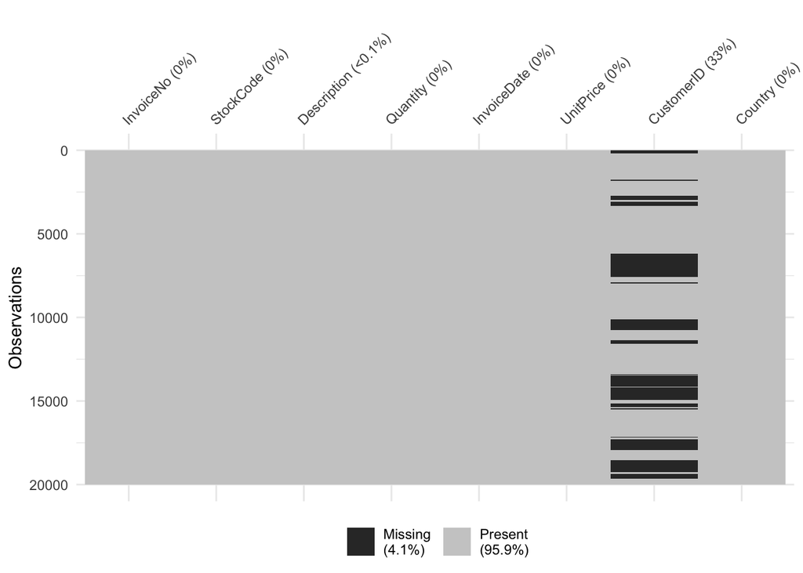

```r
vis_miss(dataset)
```

```r
head(dataset,9)
```

```
## # A tibble: 9 × 8
##   InvoiceNo StockCode Description         Quantity InvoiceDate         UnitPrice
##   <chr>     <chr>     <chr>                  <dbl> <dttm>                  <dbl>
## 1 580367    23328     SET 6 SCHOOL MILK …       16 2011-12-02 16:39:00      7.46
## 2 580367    23334     IVORY WICKER HEART…        4 2011-12-02 16:39:00      1.25
## 3 580367    23340     VINTAGE CHRISTMAS …        1 2011-12-02 16:39:00      3.29
## 4 580367    23343     JUMBO BAG VINTAGE …       67 2011-12-02 16:39:00      2.46
## 5 580367    23344     JUMBO BAG 50'S CHR…        5 2011-12-02 16:39:00      4.13
## 6 580367    23345     DOLLY GIRL BEAKER          1 2011-12-02 16:39:00      2.46
## 7 580367    23346     SPACEBOY BEAKER            3 2011-12-02 16:39:00      2.46
## 8 580367    23347     I LOVE LONDON BEAK…        1 2011-12-02 16:39:00      2.46
## 9 580367    23353     6 GIFT TAGS VINTAG…        2 2011-12-02 16:39:00      1.63
## # ℹ 2 more variables: CustomerID <dbl>, Country <chr>
```

```r
#summary of the dataset
summary(dataset)
```

```
##   InvoiceNo          StockCode         Description           Quantity
##  Length:20000       Length:20000       Length:20000       Min.   :-80995.00
##  Class :character   Class :character   Class :character   1st Qu.:     1.00
##  Mode  :character   Mode  :character   Mode  :character   Median :     3.00
##                                                           Mean   :     8.63
##                                                           3rd Qu.:    10.00
##                                                           Max.   : 80995.00
##
##   InvoiceDate                       UnitPrice           CustomerID
##  Min.   :2011-12-02 16:39:00.00   Min.   :    0.000   Min.   :12347
##  1st Qu.:2011-12-05 14:51:00.00   1st Qu.:    1.250   1st Qu.:13956
##  Median :2011-12-06 15:40:00.00   Median :    2.080   Median :14911
##  Mean   :2011-12-06 21:33:05.38   Mean   :    5.752   Mean   :15299
##  3rd Qu.:2011-12-08 09:56:00.00   3rd Qu.:    4.130   3rd Qu.:16910
##  Max.   :2011-12-09 12:50:00.00   Max.   :17836.460   Max.   :18283
##                                                       NA's   :6525
##    Country
##  Length:20000
##  Class :character
##  Mode  :character
##
##
##
##
```

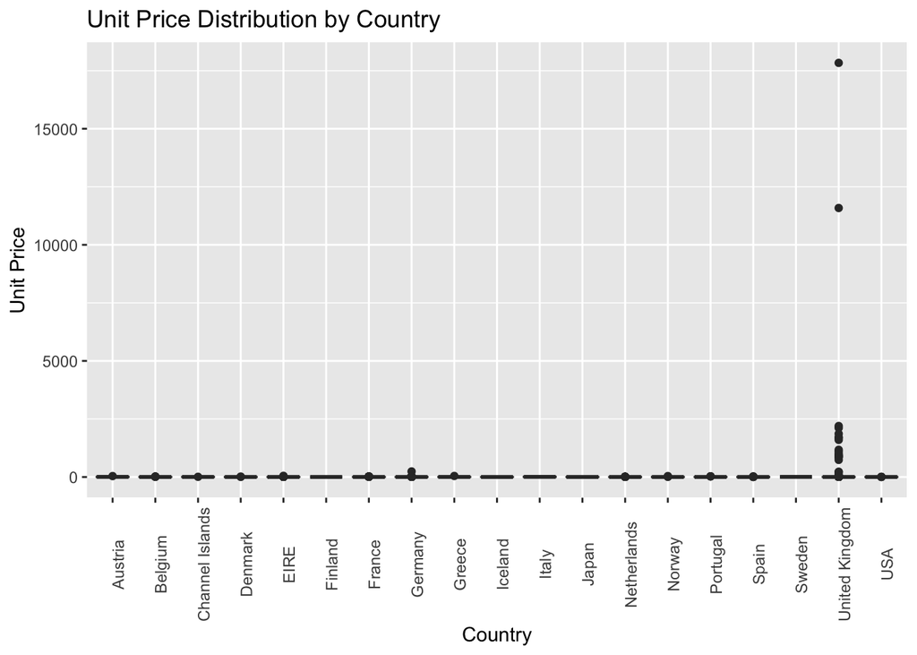

```r
ggplot(dataset, aes(x = Country, y = UnitPrice)) +
  geom_boxplot() +
  theme(axis.text.x = element_text(angle = 90)) +
  labs(title = "Unit Price Distribution by Country", x = "Country", y = "Unit Price")
```

we can observe that UK has the highest unit price

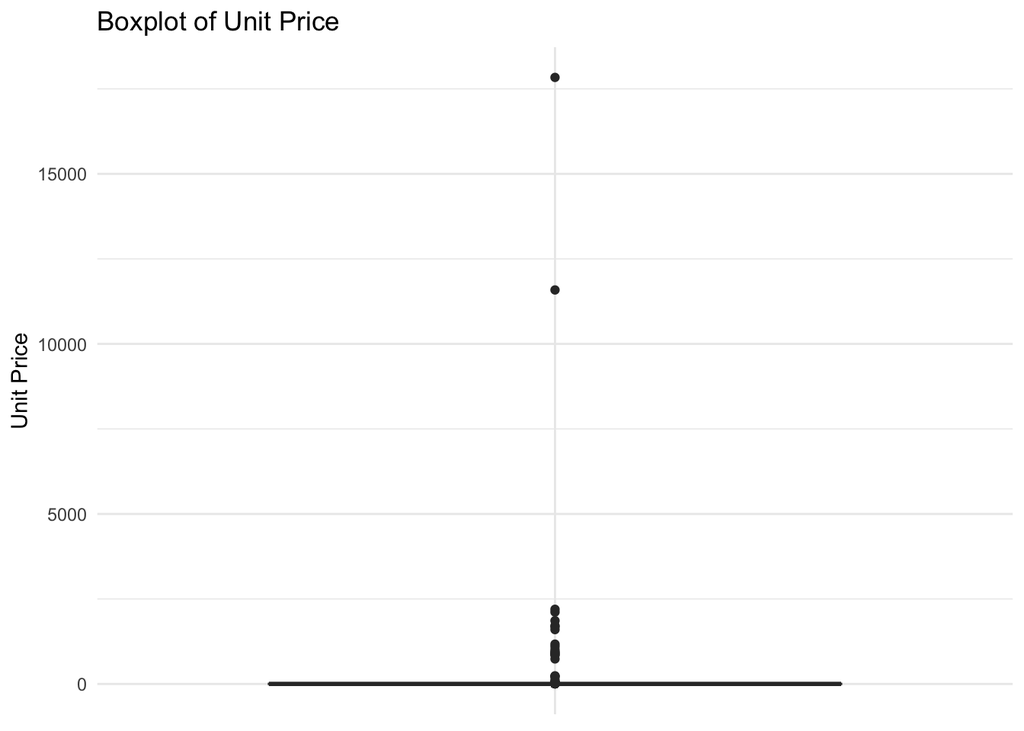

```r
# boxplot for UnitPrice
ggplot(dataset, aes(x = "", y = UnitPrice)) +
  geom_boxplot() +
  theme_minimal() +
  labs(y = "Unit Price", title = "Boxplot of Unit Price") +
  theme(axis.title.x = element_blank(),
        axis.text.x = element_blank(),
        axis.ticks.x = element_blank())
```

```r
cleaned_data <- dataset %>%filter(UnitPrice <= 2500)
cleaned_data <- cleaned_data %>%filter(UnitPrice > 0)
cleaned_data <- cleaned_data %>%filter(Quantity <= 10000)
cleaned_data <- cleaned_data %>%filter(Quantity > 0)




head(cleaned_data)
```

```
## # A tibble: 6 × 8
##   InvoiceNo StockCode Description         Quantity InvoiceDate         UnitPrice
##   <chr>     <chr>     <chr>                  <dbl> <dttm>                  <dbl>
## 1 580367    23328     SET 6 SCHOOL MILK …       16 2011-12-02 16:39:00      7.46
## 2 580367    23334     IVORY WICKER HEART…        4 2011-12-02 16:39:00      1.25
## 3 580367    23340     VINTAGE CHRISTMAS …        1 2011-12-02 16:39:00      3.29
## 4 580367    23343     JUMBO BAG VINTAGE …       67 2011-12-02 16:39:00      2.46
## 5 580367    23344     JUMBO BAG 50'S CHR…        5 2011-12-02 16:39:00      4.13
## 6 580367    23345     DOLLY GIRL BEAKER          1 2011-12-02 16:39:00      2.46
## # ℹ 2 more variables: CustomerID <dbl>, Country <chr>
```

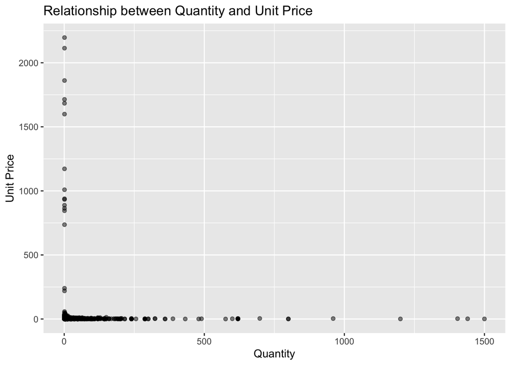

```r
ggplot(cleaned_data, aes(x = Quantity, y = UnitPrice)) +
  geom_point(alpha = 0.5) +
  labs(title = "Relationship between Quantity and Unit Price", x = "Quantity", y = "Unit Price")
```

In the dataset, invoice numbers that start with the letter ‘C’ indicate cancellations or void tickets . To remove these, as well as any other entries that may start with a different letter, we filter the dataset to only include rows where the InvoiceNo starts with a digit.

```r
cleaned_data <- cleaned_data %>%filter(!grepl("^[A-Za-z]", InvoiceNo))
```

Now lets take a look at different products in the dataset whose description is given in the dataset

```r
unique_descriptions <- cleaned_data %>%distinct(Description)


print(unique_descriptions)
```

```
## # A tibble: 2,352 × 1
##    Description
##    <chr>
##  1 SET 6 SCHOOL MILK BOTTLES IN CRATE
##  2 IVORY WICKER HEART SMALL
##  3 VINTAGE CHRISTMAS CAKE FRILL
##  4 JUMBO BAG VINTAGE CHRISTMAS
##  5 JUMBO BAG 50'S CHRISTMAS
##  6 DOLLY GIRL BEAKER
##  7 SPACEBOY BEAKER
##  8 I LOVE LONDON BEAKER
##  9 6 GIFT TAGS VINTAGE CHRISTMAS
## 10 HOT WATER BOTTLE KEEP CALM
## # ℹ 2,342 more rows
```

```r
total_unique_descriptions <- n_distinct(cleaned_data$Description)

print( total_unique_descriptions)
```

```
## [1] 2352
```

```r
# Drop all rows with NA in the Description column
cleaned_data <- cleaned_data %>%drop_na(Description)
```

```r
#  to generate unique IDs
generate_unique_id <- function(existing_ids) {
  new_id <- sample(10000:99999, 1)
  while(new_id %in% existing_ids) {
    new_id <- sample(10000:99999, 1)
  }
  return(new_id)
}

# fill in missing CustomerIDs
cleaned_data <- cleaned_data %>%
  mutate(CustomerID = ifelse(is.na(CustomerID), generate_unique_id(CustomerID), CustomerID))


head(cleaned_data)
```

```
## # A tibble: 6 × 8
##   InvoiceNo StockCode Description         Quantity InvoiceDate         UnitPrice
##   <chr>     <chr>     <chr>                  <dbl> <dttm>                  <dbl>
## 1 580367    23328     SET 6 SCHOOL MILK …       16 2011-12-02 16:39:00      7.46
## 2 580367    23334     IVORY WICKER HEART…        4 2011-12-02 16:39:00      1.25
## 3 580367    23340     VINTAGE CHRISTMAS …        1 2011-12-02 16:39:00      3.29
## 4 580367    23343     JUMBO BAG VINTAGE …       67 2011-12-02 16:39:00      2.46
## 5 580367    23344     JUMBO BAG 50'S CHR…        5 2011-12-02 16:39:00      4.13
## 6 580367    23345     DOLLY GIRL BEAKER          1 2011-12-02 16:39:00      2.46
## # ℹ 2 more variables: CustomerID <dbl>, Country <chr>
```

```r
country_counts <- cleaned_data %>%
  group_by(Country) %>%
  summarise(Count = n())


print(country_counts)
```

```
## # A tibble: 17 × 2
##    Country         Count
##    <chr>           <int>
##  1 Austria             7
##  2 Belgium            67
##  3 Channel Islands     5
##  4 Denmark            11
##  5 EIRE              285
##  6 France            226
##  7 Germany           279
##  8 Greece             36
##  9 Iceland            11
## 10 Italy               8
## 11 Netherlands        86
## 12 Norway             73
## 13 Portugal           53
## 14 Spain              65
## 15 Sweden              1
## 16 USA                21
## 17 United Kingdom  18485
```

Now lets check the customer base

```r
# Group the data by Country and count the unique CustomerIDs
unique_customers_by_country <- cleaned_data %>%
  group_by(Country) %>%
  summarise(UniqueCustomers = n_distinct(CustomerID))

# unique customer counts for each country
print(unique_customers_by_country)
```

```
## # A tibble: 17 × 2
##    Country         UniqueCustomers
##    <chr>                     <int>
##  1 Austria                       1
##  2 Belgium                       3
##  3 Channel Islands               1
##  4 Denmark                       1
##  5 EIRE                          1
##  6 France                       12
##  7 Germany                      11
##  8 Greece                        1
##  9 Iceland                       1
## 10 Italy                         1
## 11 Netherlands                   1
## 12 Norway                        2
## 13 Portugal                      3
## 14 Spain                         2
## 15 Sweden                        1
## 16 USA                           1
## 17 United Kingdom              427
```

united kingdom clearly has the highest number of customers out of all the other countries in the dataset .

Once again lets check if we still have any missing records to further proceed with our research

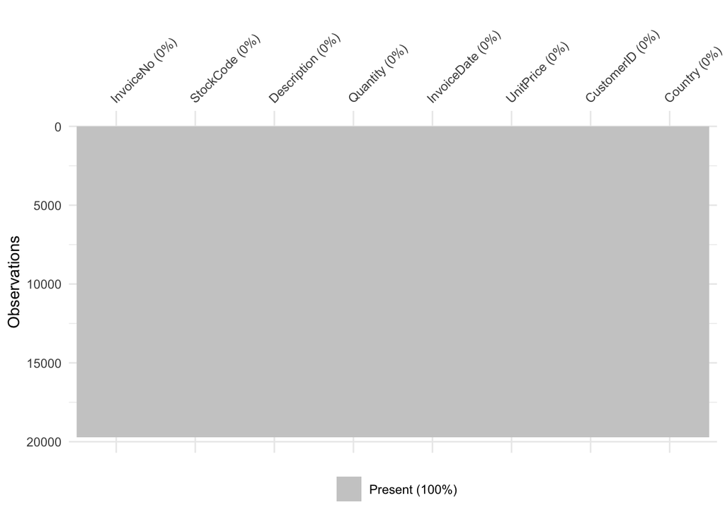

```r
vis_miss(cleaned_data)
```

As we can see our data set is cleaned and there no more na values or missing records we can proceed further for analysis of our data

## Exploratory Data Analysis

```r
iqr_quantity <- IQR(cleaned_data$Quantity, na.rm = TRUE)


Q1 <- quantile(cleaned_data$Quantity, 0.25, na.rm = TRUE)
Q3 <- quantile(cleaned_data$Quantity, 0.75, na.rm = TRUE)

lower_bound <- Q1 - 1.5 * iqr_quantity
upper_bound <- Q3 + 1.5 * iqr_quantity


cleaned_data <- cleaned_data %>%
  filter(Quantity >= lower_bound & Quantity <= upper_bound)


min_quantity <- min(cleaned_data$Quantity, na.rm = TRUE)
max_quantity <- max(cleaned_data$Quantity, na.rm = TRUE)

cat("The new range of Quantity after removing outliers is from", min_quantity, "to", max_quantity, "\n")
```

```
## The new range of Quantity after removing outliers is from 1 to 23
```

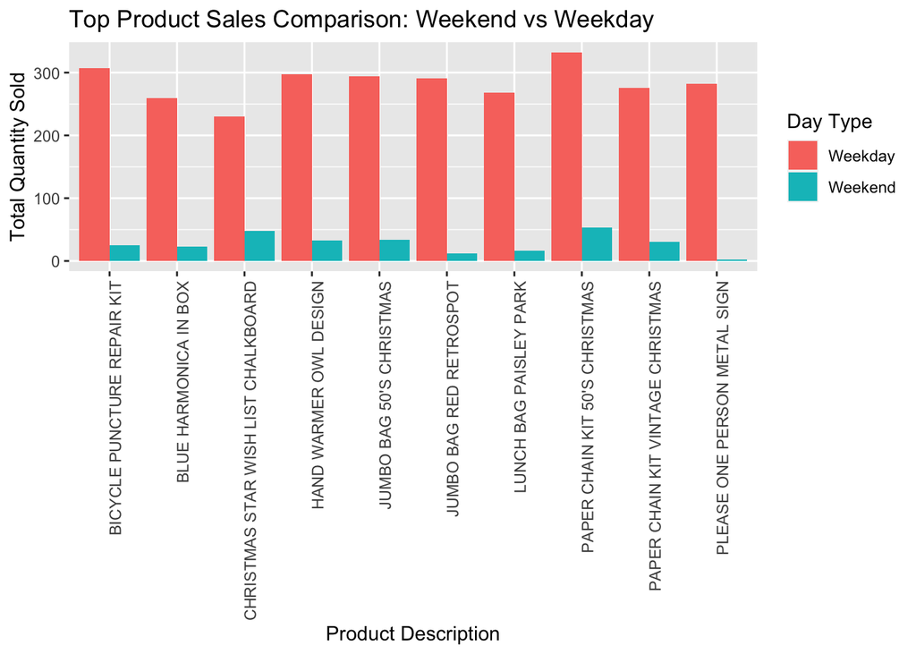

```r
cleaned_data <- cleaned_data %>%
  mutate(DayType = ifelse(weekdays(InvoiceDate) %in% c("Saturday", "Sunday"), "Weekend", "Weekday"))


top_products <- cleaned_data %>%
  group_by(Description) %>%
  summarise(TotalQuantity = sum(Quantity, na.rm = TRUE)) %>%
  ungroup() %>%
  arrange(desc(TotalQuantity)) %>%
  top_n(10, TotalQuantity) %>%
  select(Description)

top_product_sales <- cleaned_data %>%
  filter(Description %in% top_products$Description)


product_sales_comparison <- top_product_sales %>%
  group_by(Description, DayType) %>%
  summarise(TotalQuantity = sum(Quantity, na.rm = TRUE)) %>%
  ungroup()


ggplot(product_sales_comparison, aes(x = Description, y = TotalQuantity, fill = DayType)) +
  geom_bar(stat = "identity", position = "dodge") +
  theme(axis.text.x = element_text(angle = 90, hjust = 1)) +
  labs(title = "Top Product Sales Comparison: Weekend vs Weekday",
       x = "Product Description",
       y = "Total Quantity Sold",
       fill = "Day Type")
```

Let us analyse the highest number of times the product which has been sold

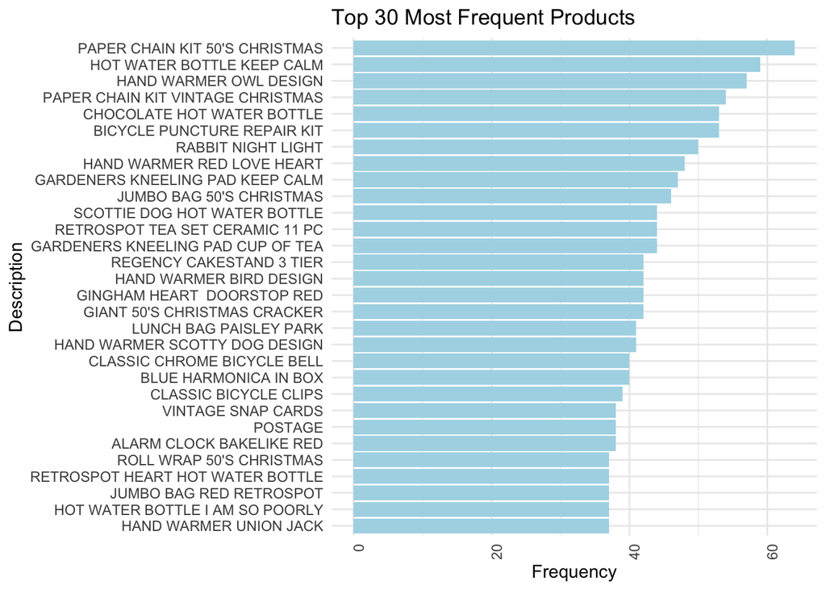

```r
library(forcats)

description_counts <- cleaned_data %>%
  count(Description, sort = TRUE)


top_n <- 30  # Adjust this number as needed

ggplot(description_counts[1:top_n, ], aes(x = reorder(Description, n), y = n)) +
  geom_col(fill = "lightblue") +
  coord_flip() +
  theme_minimal() +
  labs(x = "Description", y = "Frequency", title = paste("Top", top_n, "Most Frequent Products")) +
  theme(axis.text.x = element_text(angle = 90, hjust = 1))
```

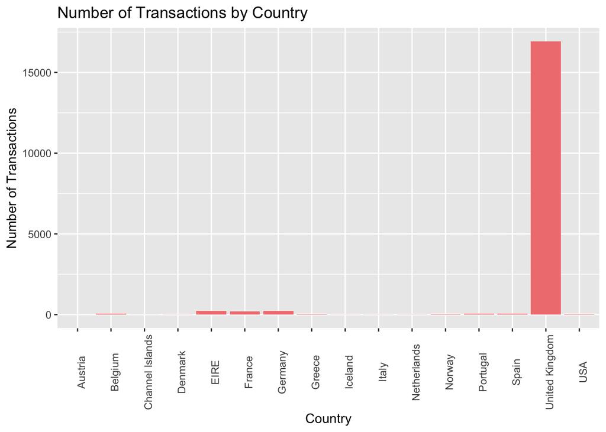

```r
ggplot(cleaned_data, aes(x = Country)) +
  geom_bar(fill = "lightcoral") +
  theme(axis.text.x = element_text(angle = 90)) +
  labs(title = "Number of Transactions by Country", x = "Country", y = "Number of Transactions")
```

```r
product_sales_by_country <- cleaned_data %>%
  group_by(Country, Description) %>%
  summarise(TotalSold = sum(Quantity, na.rm = TRUE), .groups = 'drop')

top_product_by_country <- product_sales_by_country %>%
  group_by(Country) %>%
  top_n(1, TotalSold) %>%
  ungroup()

top_product_by_country
```

```
## # A tibble: 47 × 3
##    Country         Description                    TotalSold
##    <chr>           <chr>                              <dbl>
##  1 Austria         EDWARDIAN PARASOL PINK                12
##  2 Belgium         RETRO PLASTIC POLKA TRAY              27
##  3 Channel Islands HOT WATER BOTTLE KEEP CALM            20
##  4 Denmark         CIRCUS PARADE LUNCH BOX               12
##  5 Denmark         DOLLY GIRL LUNCH BOX                  12
##  6 Denmark         SET OF 6 3D KIT CARDS FOR KIDS        12
##  7 Denmark         SPACEBOY LUNCH BOX                    12
##  8 EIRE            GIANT 50'S CHRISTMAS CRACKER          36
##  9 EIRE            HANGING METAL STAR LANTERN            36
## 10 EIRE            HOT STUFF HOT WATER BOTTLE            36
## # ℹ 37 more rows
```

```r
least_product_by_country <- product_sales_by_country %>%
  group_by(Country) %>%
  slice_min(order_by = TotalSold, n = 1) %>%
  ungroup()

least_product_by_country
```

```
## # A tibble: 288 × 3
##    Country         Description                    TotalSold
##    <chr>           <chr>                              <dbl>
##  1 Austria         POSTAGE                                4
##  2 Belgium         SPACEBOY BABY GIFT SET                 1
##  3 Channel Islands VINTAGE UNION JACK BUNTING             4
##  4 Denmark         POSTAGE                                1
##  5 EIRE            CARRIAGE                               1
##  6 EIRE            CHEST OF DRAWERS GINGHAM HEART         1
##  7 EIRE            ENAMEL BREAD BIN CREAM                 1
##  8 EIRE            IVORY CAFE HANGING LAMP                1
##  9 France          GLASS  SONGBIRD STORAGE JAR            1
## 10 Germany         TRIANGULAR POUFFE VINTAGE              1
## # ℹ 278 more rows
```

```r
sales_spain_uk <- cleaned_data %>%
  filter(Country %in% c("Spain", "United Kingdom"))


product_sales_spain_uk <- sales_spain_uk %>%
  group_by(Country, Description) %>%
  summarise(TotalSold = sum(Quantity, na.rm = TRUE), .groups = 'drop')


least_product_spain_uk <- product_sales_spain_uk %>%
  group_by(Country) %>%
  slice_min(order_by = TotalSold, n = 1) %>%
  ungroup()


print(least_product_spain_uk)
```

```
## # A tibble: 259 × 3
##    Country Description                         TotalSold
##    <chr>   <chr>                                   <dbl>
##  1 Spain   BISCUIT TIN 50'S CHRISTMAS                  1
##  2 Spain   CERAMIC CHERRY CAKE MONEY BANK              1
##  3 Spain   CERAMIC HEART FAIRY CAKE MONEY BANK         1
##  4 Spain   CHILDRENS CUTLERY DOLLY GIRL                1
##  5 Spain   CIRCUS PARADE LUNCH BOX                     1
##  6 Spain   HANGING METAL HEART LANTERN                 1
##  7 Spain   HANGING METAL STAR LANTERN                  1
##  8 Spain   HEART OF WICKER SMALL                       1
##  9 Spain   JUMBO BAG VINTAGE DOILY                     1
## 10 Spain   LUNCH BAG DOLLY GIRL DESIGN                 1
## # ℹ 249 more rows
```

```r
#  the range of Quantity
min_quantity <- min(cleaned_data$Quantity, na.rm = TRUE)
max_quantity <- max(cleaned_data$Quantity, na.rm = TRUE)


cat("The range of Quantity is from", min_quantity, "to", max_quantity, "\n")
```

```
## The range of Quantity is from 1 to 23
```

Now lets add some new variables to our cleaned dataset for deep insights . we can add varibables such as ‘purchase_frequency’ , ‘season’, ‘totalprice’ and also we can break down the time into date , month , year etc so that it can help us do any time series analysis in fututre.

```r
purchase_frequency <- cleaned_data %>%
  group_by(CustomerID) %>%
  summarise(PurchaseFrequency = n_distinct(InvoiceNo))
cleaned_data <- merge(cleaned_data, purchase_frequency, by = "CustomerID")

cleaned_data$Season <- cut(as.numeric(format(cleaned_data$InvoiceDate, "%m")),
                              breaks = c(1, 3, 6, 9, 12),
                              labels = c("Winter", "Spring", "Summer", "Autumn"),
                              include.lowest = TRUE)

cleaned_data$totalprice <- cleaned_data$Quantity * cleaned_data$UnitPrice



cleaned_data$Year <- format(cleaned_data$InvoiceDate, "%Y")
cleaned_data$Month <- format(cleaned_data$InvoiceDate, "%m")
cleaned_data$Day <- format(cleaned_data$InvoiceDate, "%d")
cleaned_data$Hour <- format(cleaned_data$InvoiceDate, "%H")
cleaned_data$Weekday <- weekdays(cleaned_data$InvoiceDate)





head(cleaned_data,9)
```

```
##   CustomerID InvoiceNo StockCode                         Description Quantity
## 1      12347    581180     23497         CLASSIC CHROME BICYCLE BELL       12
## 2      12347    581180     23552         BICYCLE PUNCTURE REPAIR KIT        6
## 3      12347    581180     23508       MINI PLAYING CARDS DOLLY GIRL       20
## 4      12347    581180     20719              WOODLAND CHARLOTTE BAG       10
## 5      12347    581180     23506         MINI PLAYING CARDS SPACEBOY       20
## 6      12347    581180     21265        PINK GOOSE FEATHER TREE 60CM       12
## 7      12347    581180     23271 CHRISTMAS TABLE SILVER CANDLE SPIKE       16
## 8      12358    581232    15056P              EDWARDIAN PARASOL PINK       12
## 9      12358    581232      POST                             POSTAGE        4
##           InvoiceDate UnitPrice Country DayType PurchaseFrequency Season
## 1 2011-12-07 15:52:00      1.45 Iceland Weekday                 1 Autumn
## 2 2011-12-07 15:52:00      2.08 Iceland Weekday                 1 Autumn
## 3 2011-12-07 15:52:00      0.42 Iceland Weekday                 1 Autumn
## 4 2011-12-07 15:52:00      0.85 Iceland Weekday                 1 Autumn
## 5 2011-12-07 15:52:00      0.42 Iceland Weekday                 1 Autumn
## 6 2011-12-07 15:52:00      1.95 Iceland Weekday                 1 Autumn
## 7 2011-12-07 15:52:00      0.83 Iceland Weekday                 1 Autumn
## 8 2011-12-08 10:26:00      5.95 Austria Weekday                 1 Autumn
## 9 2011-12-08 10:26:00     40.00 Austria Weekday                 1 Autumn
##   totalprice Year Month Day Hour   Weekday
## 1      17.40 2011    12  07   15 Wednesday
## 2      12.48 2011    12  07   15 Wednesday
## 3       8.40 2011    12  07   15 Wednesday
## 4       8.50 2011    12  07   15 Wednesday
## 5       8.40 2011    12  07   15 Wednesday
## 6      23.40 2011    12  07   15 Wednesday
## 7      13.28 2011    12  07   15 Wednesday
## 8      71.40 2011    12  08   10  Thursday
## 9     160.00 2011    12  08   10  Thursday
```

Now let us analyse which season has the highest sale

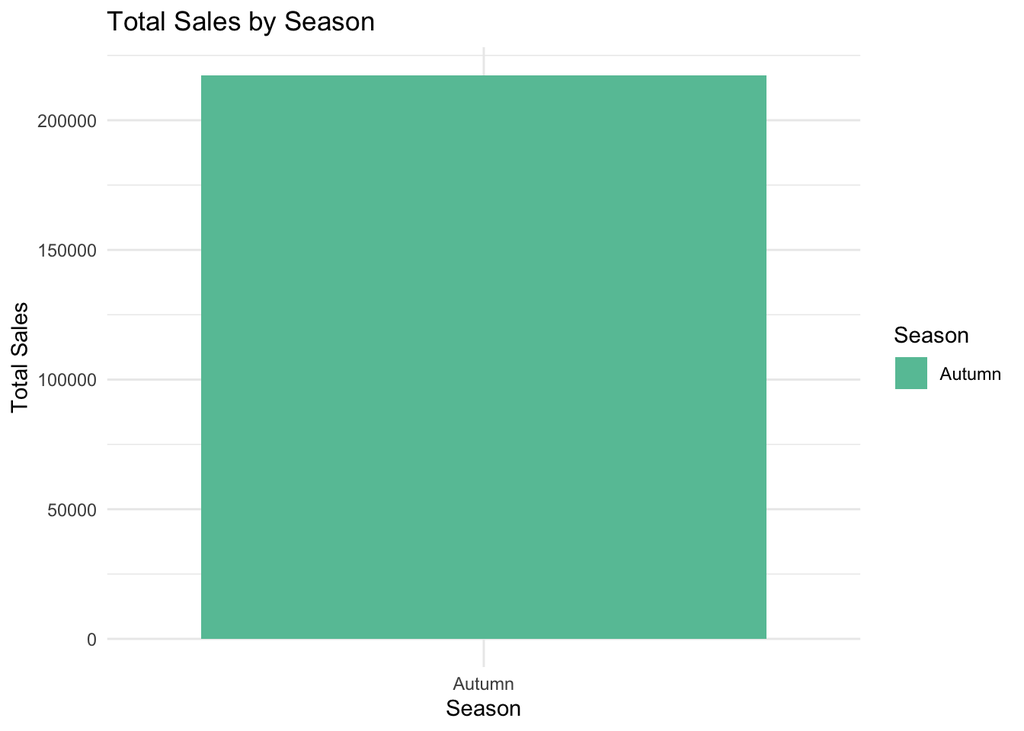

```r
season_sales <- cleaned_data %>%
  group_by(Season) %>%
  summarise(TotalSales = sum(totalprice, na.rm = TRUE))


ggplot(season_sales, aes(x = Season, y = TotalSales, fill = Season)) +
  geom_bar(stat = "identity") +
  labs(title = "Total Sales by Season", x = "Season", y = "Total Sales") +
  theme_minimal() +
  scale_fill_brewer(palette = "Set2")  # For a more colorful graph
```

The above graph indicates that the dataset contains only the transaction history of the autumn season so we might not able to mine any seasonal analysis . lets do the same analysis on the weekday

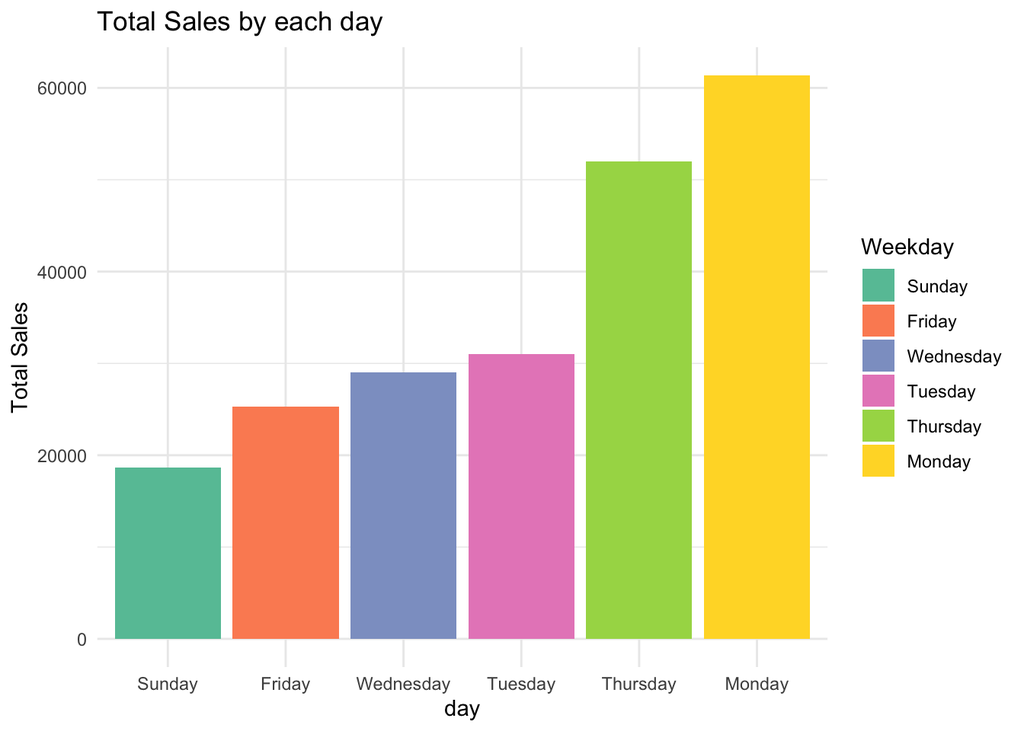

```r
weekday_sales <- cleaned_data %>%
  group_by(Weekday) %>%
  summarise(TotalSales = sum(totalprice, na.rm = TRUE))
weekday_sales$Weekday <- reorder(weekday_sales$Weekday, weekday_sales$TotalSales)



ggplot(weekday_sales, aes(x = Weekday, y = TotalSales, fill = Weekday)) +
  geom_bar(stat = "identity") +
  labs(title = "Total Sales by each day", x = "day", y = "Total Sales") +
  theme_minimal() +
  scale_fill_brewer(palette = "Set2")  # For a more colorful graph
```

As we can see out of all the weekdays mondays has the highest amount of total sales . further we can analyze which hour has the highest sale on monday

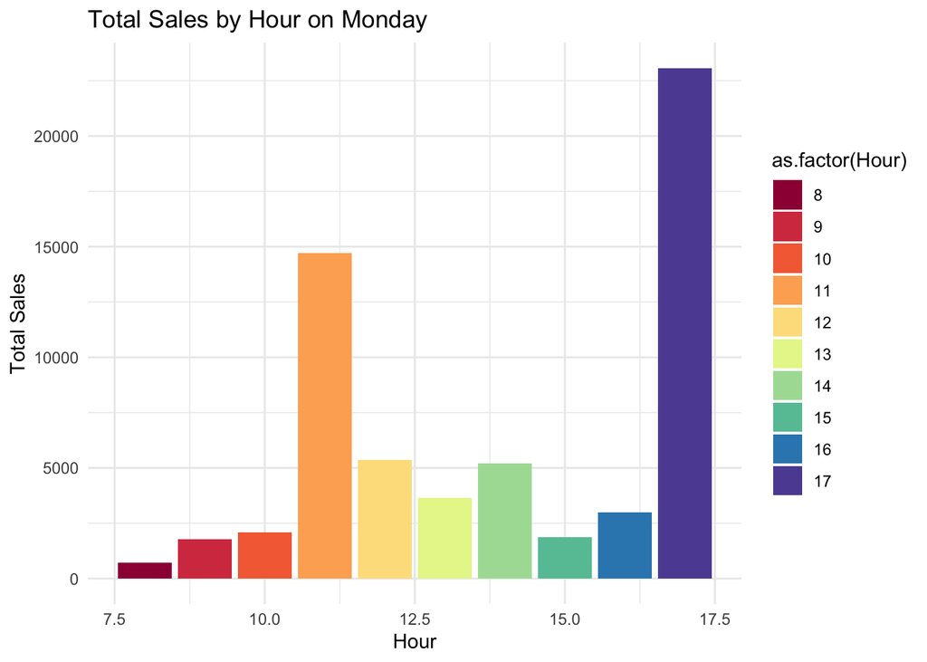

```r
cleaned_data$Hour <- as.integer(format(cleaned_data$InvoiceDate, "%H"))
cleaned_data$Weekday <- weekdays(cleaned_data$InvoiceDate)

monday_sales <- cleaned_data %>%
  filter(Weekday == "Monday") %>%
  group_by(Hour) %>%
  summarise(TotalSales = sum(totalprice, na.rm = TRUE))

ggplot(monday_sales, aes(x = Hour, y = TotalSales, fill = as.factor(Hour))) +
  geom_bar(stat = "identity") +
  labs(title = "Total Sales by Hour on Monday", x = "Hour", y = "Total Sales") +
  theme_minimal() +
  scale_fill_brewer(palette = "Spectral")  # Optional for color
```

We can see the 17 th hour has the highest amount of sale. now we can check for what are the products sold the most on mondays.

```r
cleaned_data$Weekday <- weekdays(cleaned_data$InvoiceDate)


monday_product_sales <- cleaned_data%>%
  filter(Weekday == "Monday") %>%
  group_by(Description) %>%
  summarise(TotalSold = sum(Quantity, na.rm = TRUE)) %>%
  arrange(desc(TotalSold))


top_30_monday_products <- head(monday_product_sales, 30)


top_30_monday_products
```

```
## # A tibble: 30 × 2
##    Description                         TotalSold
##    <chr>                                   <dbl>
##  1 DOUGHNUT LIP GLOSS                        120
##  2 PLEASE ONE PERSON METAL SIGN              119
##  3 PAPER CHAIN KIT 50'S CHRISTMAS            108
##  4 BICYCLE PUNCTURE REPAIR KIT               107
##  5 HAND WARMER UNION JACK                    107
##  6 ROLL WRAP VINTAGE CHRISTMAS               107
##  7 LARGE PURPLE BABUSHKA NOTEBOOK             98
##  8 HAND WARMER OWL DESIGN                     97
##  9 LARGE RED BABUSHKA NOTEBOOK                97
## 10 CHRISTMAS STAR WISH LIST CHALKBOARD        92
## # ℹ 20 more rows
```

Now that we know what sells the most and where it sells let us try to find patterns and association rules using Market Basket Analysis.

## Market Basket analysis

- Market Basket Analysis (MBA) is a data mining technique used to uncover the relationships between items in large datasets, typically in the context of shopping transactions.
- MBA is used to analyze customer purchasing patterns by finding combinations of items that occur together frequently in transactions.
- One of the most common algorithms used in MBA. It operates by identifying the frequent individual items in the database and extending them to larger itemsets as long as those itemsets appear sufficiently often in the database
- It primarily uses rules to identify the likelihood of items being purchased together. These rules are defined with measures like support, confidence, and lift.
- A higher support means the itemset is more common.
- Confidence gives the probability of purchasing a particular item when another item is already bought. It’s a measure of the strength of the association.
- A lift greater than 1 indicates a positive relationship

```r
transactions <- cleaned_data %>%
  group_by(InvoiceNo) %>%
  summarise(Products = list(Description))

transactions <- as(transactions$Products, "transactions")
```

```r
rules <- apriori(transactions,parameter = list(supp = 0.05, conf = 0.1))
```

```
## Apriori
##
## Parameter specification:
##  confidence minval smax arem  aval originalSupport maxtime support minlen
##         0.1    0.1    1 none FALSE            TRUE       5    0.05      1
##  maxlen target  ext
##      10  rules TRUE
##
## Algorithmic control:
##  filter tree heap memopt load sort verbose
##     0.1 TRUE TRUE  FALSE TRUE    2    TRUE
##
## Absolute minimum support count: 27
##
## set item appearances ...[0 item(s)] done [0.00s].
## set transactions ...[2285 item(s), 547 transaction(s)] done [0.00s].
## sorting and recoding items ... [64 item(s)] done [0.00s].
## creating transaction tree ... done [0.00s].
## checking subsets of size 1 2 done [0.00s].
## writing ... [14 rule(s)] done [0.00s].
## creating S4 object  ... done [0.00s].
```

```r
rules = apriori(transactions, parameter = list(support =0.05, confidence = 0.7, target = "rules"))
```

```
## Apriori
##
## Parameter specification:
##  confidence minval smax arem  aval originalSupport maxtime support minlen
##         0.7    0.1    1 none FALSE            TRUE       5    0.05      1
##  maxlen target  ext
##      10  rules TRUE
##
## Algorithmic control:
##  filter tree heap memopt load sort verbose
##     0.1 TRUE TRUE  FALSE TRUE    2    TRUE
##
## Absolute minimum support count: 27
##
## set item appearances ...[0 item(s)] done [0.00s].
## set transactions ...[2285 item(s), 547 transaction(s)] done [0.00s].
## sorting and recoding items ... [64 item(s)] done [0.00s].
## creating transaction tree ... done [0.00s].
## checking subsets of size 1 2 done [0.00s].
## writing ... [5 rule(s)] done [0.00s].
## creating S4 object  ... done [0.00s].
```

```r
rules
```

```
## set of 5 rules
```

```r
inspect(head(sort(rules, by = "confidence"), 5))
```

```
##     lhs                                    rhs                                   support confidence   coverage     lift count
## [1] {HAND WARMER BIRD DESIGN}           => {HAND WARMER OWL DESIGN}           0.06398537  0.8333333 0.07678245 8.441358    35
## [2] {CLASSIC BICYCLE CLIPS}             => {BICYCLE PUNCTURE REPAIR KIT}      0.05484461  0.7894737 0.06946984 8.636842    30
## [3] {HAND WARMER SCOTTY DOG DESIGN}     => {HAND WARMER OWL DESIGN}           0.05484461  0.7500000 0.07312614 7.597222    30
## [4] {GARDENERS KNEELING PAD CUP OF TEA} => {GARDENERS KNEELING PAD KEEP CALM} 0.05850091  0.7441860 0.07861060 8.849343    32
## [5] {HAND WARMER RED LOVE HEART}        => {HAND WARMER OWL DESIGN}           0.05850091  0.7272727 0.08043876 7.367003    32
```

```r
rules <- apriori(transactions,parameter = list(supp = 0.05, conf = 0.1))
```

```
## Apriori
##
## Parameter specification:
##  confidence minval smax arem  aval originalSupport maxtime support minlen
##         0.1    0.1    1 none FALSE            TRUE       5    0.05      1
##  maxlen target  ext
##      10  rules TRUE
##
## Algorithmic control:
##  filter tree heap memopt load sort verbose
##     0.1 TRUE TRUE  FALSE TRUE    2    TRUE
##
## Absolute minimum support count: 27
##
## set item appearances ...[0 item(s)] done [0.00s].
## set transactions ...[2285 item(s), 547 transaction(s)] done [0.00s].
## sorting and recoding items ... [64 item(s)] done [0.00s].
## creating transaction tree ... done [0.00s].
## checking subsets of size 1 2 done [0.00s].
## writing ... [14 rule(s)] done [0.00s].
## creating S4 object  ... done [0.00s].
```

```r
inspect(head(sort(rules, by = "confidence"), 10))
```

```
##      lhs                                    rhs                                    support confidence   coverage     lift count
## [1]  {HAND WARMER BIRD DESIGN}           => {HAND WARMER OWL DESIGN}            0.06398537  0.8333333 0.07678245 8.441358    35
## [2]  {CLASSIC BICYCLE CLIPS}             => {BICYCLE PUNCTURE REPAIR KIT}       0.05484461  0.7894737 0.06946984 8.636842    30
## [3]  {HAND WARMER SCOTTY DOG DESIGN}     => {HAND WARMER OWL DESIGN}            0.05484461  0.7500000 0.07312614 7.597222    30
## [4]  {GARDENERS KNEELING PAD CUP OF TEA} => {GARDENERS KNEELING PAD KEEP CALM}  0.05850091  0.7441860 0.07861060 8.849343    32
## [5]  {HAND WARMER RED LOVE HEART}        => {HAND WARMER OWL DESIGN}            0.05850091  0.7272727 0.08043876 7.367003    32
## [6]  {GARDENERS KNEELING PAD KEEP CALM}  => {GARDENERS KNEELING PAD CUP OF TEA} 0.05850091  0.6956522 0.08409506 8.849343    32
## [7]  {HAND WARMER OWL DESIGN}            => {HAND WARMER BIRD DESIGN}           0.06398537  0.6481481 0.09872029 8.441358    35
## [8]  {BICYCLE PUNCTURE REPAIR KIT}       => {CLASSIC BICYCLE CLIPS}             0.05484461  0.6000000 0.09140768 8.636842    30
## [9]  {HAND WARMER OWL DESIGN}            => {HAND WARMER RED LOVE HEART}        0.05850091  0.5925926 0.09872029 7.367003    32
## [10] {PAPER CHAIN KIT VINTAGE CHRISTMAS} => {PAPER CHAIN KIT 50'S CHRISTMAS}    0.05301645  0.5576923 0.09506399 5.170469    29
```

1. **{HAND WARMER BIRD DESIGN} => {HAND WARMER OWL DESIGN}**
   - This rule has a very high confidence of 83.33%, meaning that when customers buy Hand Warmers with a Bird Design, there’s a strong likelihood they will also buy Hand Warmers with an Owl Design. The lift of 8.44 suggests that Hand Warmers with an Owl Design are over 8 times more likely to be purchased by customers who buy Hand Warmers with a Bird Design than by the average customer, indicating a strong positive relationship between the two products.
2. **{CLASSIC BICYCLE CLIPS} => {BICYCLE PUNCTURE REPAIR KIT}**
   - With a confidence of 78.95%, customers purchasing Classic Bicycle Clips are also very likely to purchase a Bicycle Puncture Repair Kit. The lift of 8.64 indicates that customers who buy Classic Bicycle Clips are over 8 times more likely to buy a Bicycle Puncture Repair Kit than the average customer.
3. **{HAND WARMER SCOTTY DOG DESIGN} => {HAND WARMER OWL DESIGN}**
   - The rule suggests a 75% confidence that customers who buy Hand Warmers with a Scotty Dog Design will also buy those with an Owl Design. The lift of 7.6 suggests these customers are about 7.5 times more likely to buy Hand Warmers with an Owl Design compared to the average customer, which is a strong affinity but slightly less than the first rule.
4. **{GARDENERS KNEELING PAD CUP OF TEA} => {GARDENERS KNEELING PAD KEEP CALM}**
   - There’s a 74.42% chance that customers who buy a Gardener’s Kneeling Pad with a Cup of Tea design will also buy one with a Keep Calm design. The high lift value of 8.85 indicates that these two products are purchased together much more frequently than would be expected if they were independent of each other.
5. **{HAND WARMER RED LOVE HEART} => {HAND WARMER OWL DESIGN}**
   - Customers who purchase a Hand Warmer with a Red Love Heart design have a 72.73% probability of also purchasing a Hand Warmer with an Owl Design. The lift of 7.37 means that the presence of a Red Love Heart design has a strong influence on the purchase of the Owl Design, more than 7 times the average likelihood.

These top 5 rules suggest that Hand Warmers with different designs are frequently purchased together, possibly as gifts or collectibles. The Gardener’s Kneeling Pads also show a strong cross-purchase pattern, indicating that customers may like to collect or give matching sets.

## Recency ,Frequency ,Monetary

RFM (Recency, Frequency, Monetary) analysis is a marketing technique for analyzing customer value based on past purchasing behavior. Here are the basic aspects of RFM:

- Recency (R): Refers to how recently a customer made a purchase. A more recent purchase scores higher because recent customers are more likely to respond to new offers.
- Frequency (F): Indicates how often a customer makes a purchase within a given time frame. Frequent buyers are often more engaged and potentially more profitable.
- Monetary (M): Reflects how much money a customer spends over a period of time. Customers who spend more are often considered more valuable.

```r
cleaned_data$InvoiceDate <- as.Date(cleaned_data$InvoiceDate)

#Monetary value for each transaction
cleaned_data$MonetaryValue <- cleaned_data$Quantity * cleaned_data$UnitPrice

#most recent date in our dataset for recency calculation
most_recent_date <- max(cleaned_data$InvoiceDate) + 1

# RFM analysis
rfm_data <- cleaned_data %>%
  group_by(CustomerID) %>%
  summarise(
    Recency = as.numeric(difftime(most_recent_date, max(InvoiceDate), units = "days")),
    Frequency = n(),
    Monetary = sum(MonetaryValue)
  )


head(rfm_data)
```

```
## # A tibble: 6 × 4
##   CustomerID Recency Frequency Monetary
##        <dbl>   <dbl>     <int>    <dbl>
## 1      12347       3         7     91.9
## 2      12358       2         2    231.
## 3      12362       4        30    529.
## 4      12367       5         8    135.
## 5      12381       5         4    107.
## 6      12417       4        17    338.
```

```r
rfm_data <- rfm_data %>%
  mutate(
    R_Score = ntile(Recency, 4),
    F_Score = ntile(Frequency, 4),
    M_Score = ntile(Monetary, 4)
  )


head(rfm_data)
```

```
## # A tibble: 6 × 7
##   CustomerID Recency Frequency Monetary R_Score F_Score M_Score
##        <dbl>   <dbl>     <int>    <dbl>   <int>   <int>   <int>
## 1      12347       3         7     91.9       2       1       1
## 2      12358       2         2    231.        1       1       3
## 3      12362       4        30    529.        2       4       4
## 4      12367       5         8    135.        3       2       2
## 5      12381       5         4    107.        3       1       1
## 6      12417       4        17    338.        2       3       3
```

- RFM helps segment customers into groups for targeted marketing based on their RFM scores, here we gonna segment it as “Hibernating”,“Loyal customer” , “other”, “cant lose them” and ” High value customers”

```r
assign_segment <- function(r_score, f_score, m_score) {
  if (r_score >= 3 & f_score >= 3 & m_score >= 3) {
    return('High-Value Customers')
  } else if (f_score >= 3) {
    return('Loyal Customers')
  } else if (r_score <= 1 & (f_score >= 2 | m_score >= 2)) {
    return('At Risk')
  } else if (r_score <= 1 & f_score <= 1 & m_score >= 3) {
    return('Can’t Lose Them')
  } else if (r_score <= 1 & f_score <= 1 & m_score <= 1) {
    return('Hibernating')
  } else {
    return('Other')
  }
}

rfm_data$Segment <- apply(rfm_data, 1, function(x) assign_segment(x['R_Score'], x['F_Score'], x['M_Score']))


head(rfm_data)
```

```
## # A tibble: 6 × 8
##   CustomerID Recency Frequency Monetary R_Score F_Score M_Score Segment
##        <dbl>   <dbl>     <int>    <dbl>   <int>   <int>   <int> <chr>
## 1      12347       3         7     91.9       2       1       1 Other
## 2      12358       2         2    231.        1       1       3 At Risk
## 3      12362       4        30    529.        2       4       4 Loyal Customers
## 4      12367       5         8    135.        3       2       2 Other
## 5      12381       5         4    107.        3       1       1 Other
## 6      12417       4        17    338.        2       3       3 Loyal Customers
```

```r
# Selecting only 'Monetary', 'Frequency', and 'Recency' columns
rfm_df <- rfm_data %>%
  select(Monetary, Frequency, Recency)

head(rfm_df)
```

```
## # A tibble: 6 × 3
##   Monetary Frequency Recency
##      <dbl>     <int>   <dbl>
## 1     91.9         7       3
## 2    231.          2       2
## 3    529.         30       4
## 4    135.          8       5
## 5    107.          4       5
## 6    338.         17       4
```

## Elbow Plot

This graph is known as “elbow plot,” which is commonly used to determine the optimal number of clusters in K-means clustering, a type of unsupervised machine learning algorithm. This graph plots the total within-cluster sum of squares (WSS) against the number of clusters K.

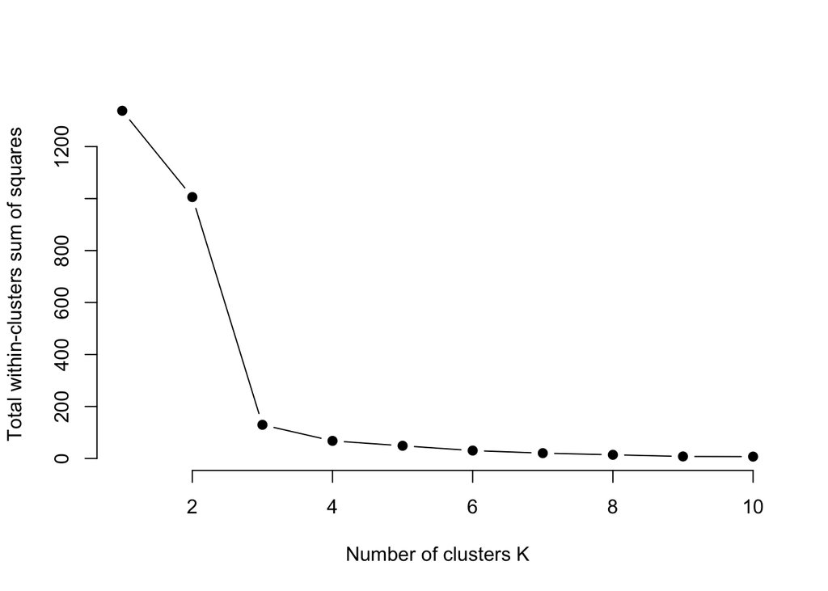

```r
rfm_scaled <- scale(rfm_df)

# Elbow Method
wss <- sapply(1:10, function(k){
  kmeans(rfm_scaled, centers = k, nstart = 20)$tot.withinss
})
plot(1:10, wss, type = "b", pch = 19, frame = FALSE,
     xlab = "Number of clusters K", ylab = "Total within-clusters sum of squares")
```

## K - Means Clustering

K-means clustering is an unsupervised learning algorithm that groups data into K distinct clusters based on feature similarity. The process involves:

- Selecting K initial centroids (mean points).
- Assigning each data point to the nearest centroid.
- Recalculating centroids based on the assigned points.
- Iterating the assignment and recalculations until centroids stabilize.
- Determining the optimal K usually requires methods like the elbow technique.

```r
#  k-means clustering

num_clusters <- 4
set.seed(111)
kmeans_result <- kmeans(rfm_scaled, centers = num_clusters, nstart = 25)


rfm_df$Cluster <- kmeans_result$cluster


head(rfm_df)
```

```
## # A tibble: 6 × 4
##   Monetary Frequency Recency Cluster
##      <dbl>     <int>   <dbl>   <int>
## 1     91.9         7       3       4
## 2    231.          2       2       1
## 3    529.         30       4       4
## 4    135.          8       5       3
## 5    107.          4       5       3
## 6    338.         17       4       4
```

```r
cluster_summary <- rfm_df %>%
  group_by(Cluster) %>%
  summarise(
    Avg_Recency = mean(Recency),
    Avg_Frequency = mean(Frequency),
    Avg_Monetary = mean(Monetary),
    .groups = 'drop'
  )


print(cluster_summary)
```

```
## # A tibble: 4 × 4
##   Cluster Avg_Recency Avg_Frequency Avg_Monetary
##     <int>       <dbl>         <dbl>        <dbl>
## 1       1        1.77          28.6         331.
## 2       2        1           6374         85725.
## 3       3        5.42          29.0         312.
## 4       4        3.50          21.0         254.
```

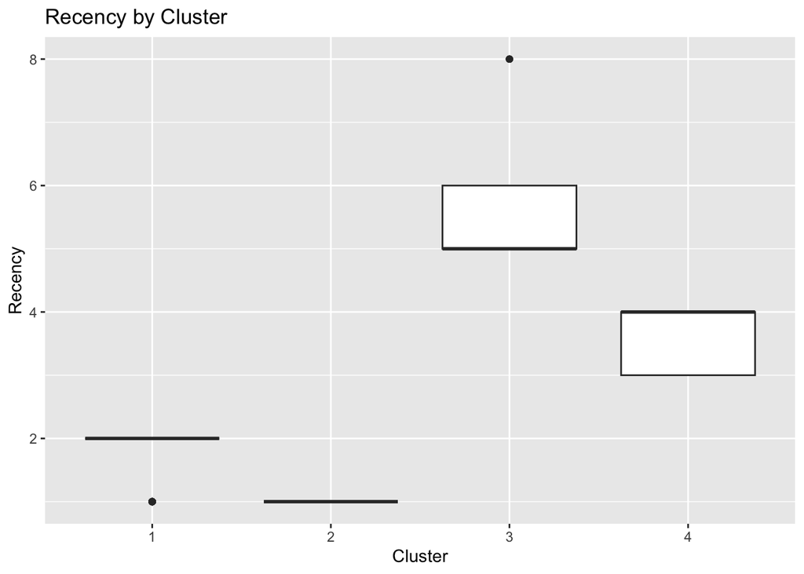

```r
# Recency
ggplot(rfm_df, aes(x = factor(Cluster), y = Recency)) +
  geom_boxplot() +
  labs(title = "Recency by Cluster", x = "Cluster", y = "Recency")
```

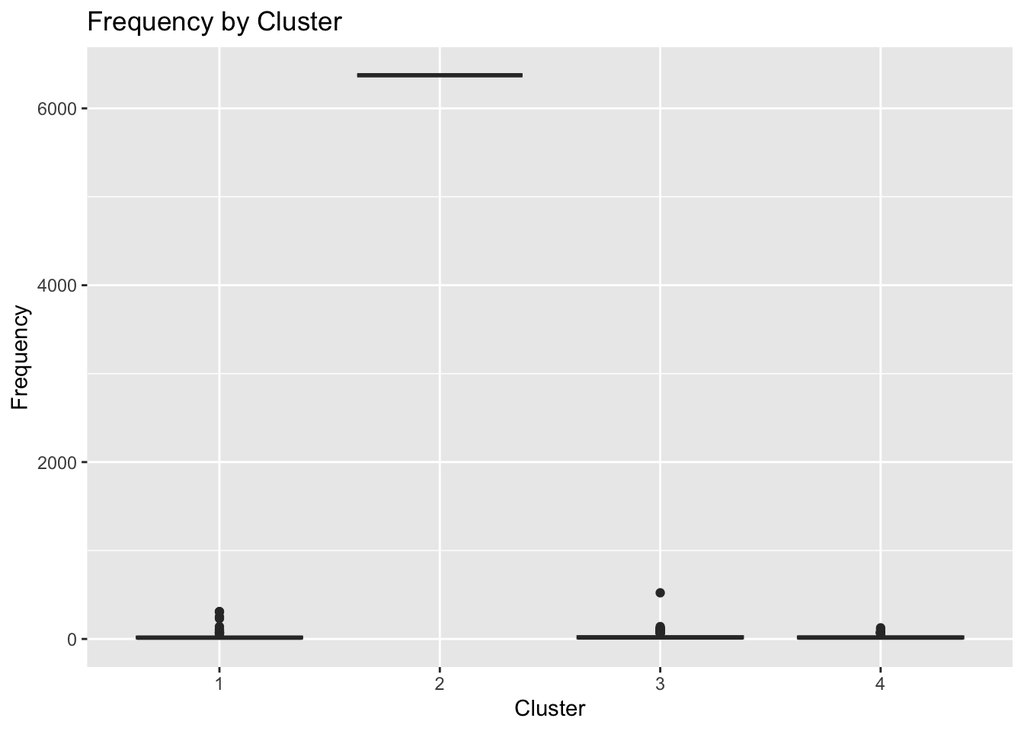

```r
# Frequency
ggplot(rfm_df, aes(x = factor(Cluster), y = Frequency)) +
  geom_boxplot() +
  labs(title = "Frequency by Cluster", x = "Cluster", y = "Frequency")
```

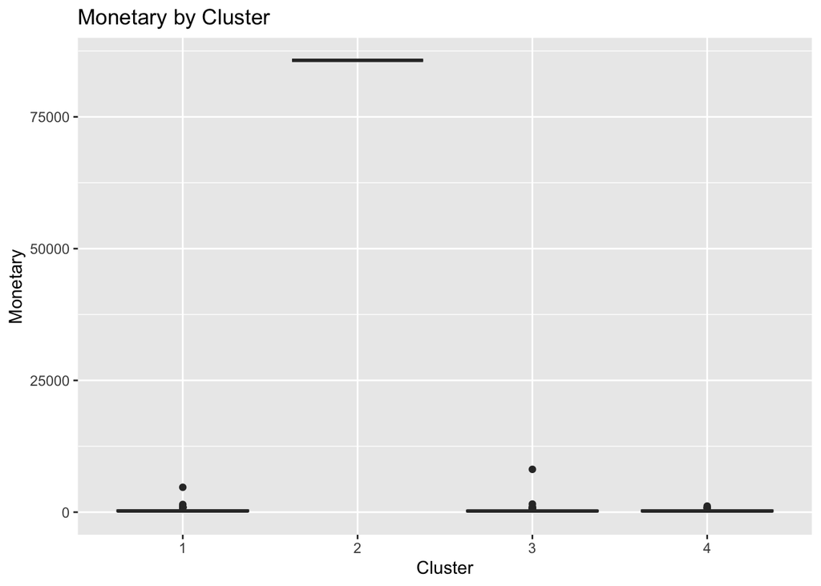

```r
# Monetary
ggplot(rfm_df, aes(x = factor(Cluster), y = Monetary)) +
  geom_boxplot() +
  labs(title = "Monetary by Cluster", x = "Cluster", y = "Monetary")
```